# SWCarpentry_Final_Project

Ahmad Hakeem

February 22, 2015

Using an Rmd file, create a short analysis report using R of the gapminder dataset.

1. Move into your R project working directory (the one you have been working with for git and github).

```r
require(ggplot2)
require(plyr)
require(ggthemes)
require(reshape2)
require(MASS)
mydata = read.table(file="~/git_demo_iplant/output/combined_gapMinder.tsv", sep="\t", header=TRUE)
```

2. Take a look at the file that resulted from our scripts this morning (which should be in the output folder, and pick three countries you are interested in.

```r
head(mydata)
```

```
##       country year      pop continent lifeExp gdpPercap
## 1 Afghanistan 1997 22227415      Asia  41.763  635.3414
## 2 Afghanistan 2002 25268405      Asia  42.129  726.7341
## 3 Afghanistan 2007 31889923      Asia  43.828  974.5803
## 4 Afghanistan 1952  8425333      Asia  28.801  779.4453
## 5 Afghanistan 1957  9240934      Asia  30.332  820.8530
## 6 Afghanistan 1962 10267083      Asia  31.997  853.1007
```

3. Write an Rmd script to load the data file, select all the data for that country (hint, use the subset() function), and use ggplot make a three scatter plots (one for each country) that has year on the x-axis and GDP on the y axis. Make sure you load all the libraries you might need (ggplot2, reshape2, etc). Describe any trends you see for each country using markdown text.

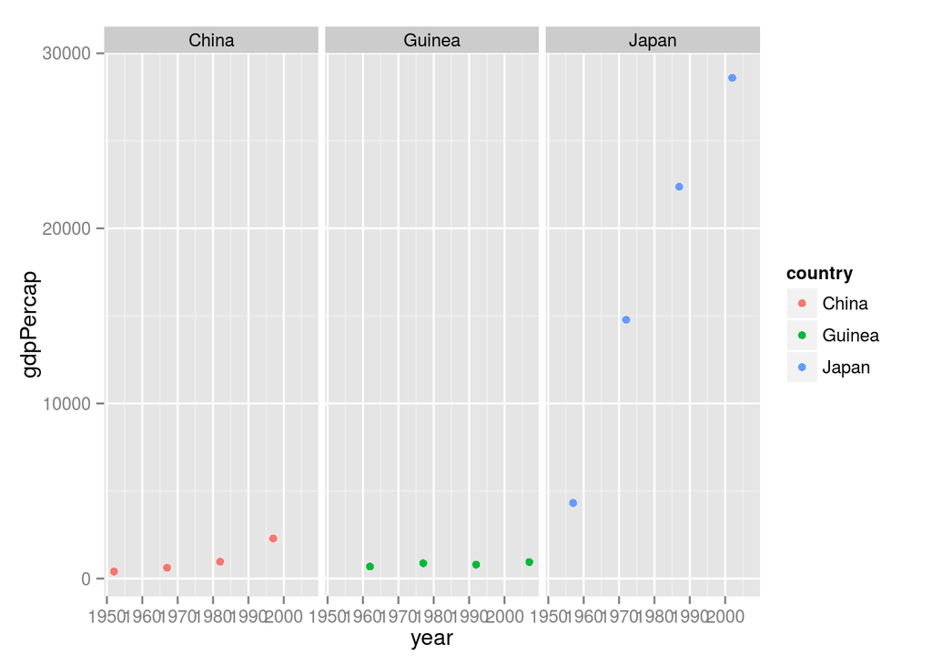

```r
mydata_subset = subset(mydata, country == c("China", "Japan", "Guinea"))
ggplot(mydata_subset, aes(year, gdpPercap, color=country)) + geom_point() + facet_grid(. ~ country)
```

4. Commit your changes using git. You can do this from the command line or in RStudio if you like.

5. Calculate the mean, min, and max life expectancies for each continent (hint: you use aggregate() if you like). Describe what you see in the results using a markdown text.

```r
aggdata_mean <- aggregate(mydata$lifeExp, by=list(mydata$continent), FUN=mean, na.rm=TRUE)
aggdata_min <- aggregate(mydata$lifeExp, by=list(mydata$continent), FUN=min, na.rm=TRUE)
aggdata_max <- aggregate(mydata$lifeExp, by=list(mydata$continent), FUN=max, na.rm=TRUE)
print(aggdata_mean)
```

```
##    Group.1        x
## 1   Africa 48.87362
## 2 Americas 64.65874
## 3     Asia 60.06490
## 4   Europe 71.90369
## 5  Oceania 74.32621
```

```r
print(aggdata_min)
```

```
##    Group.1      x
## 1   Africa 23.599
## 2 Americas 37.579
## 3     Asia 28.801
## 4   Europe 43.585
## 5  Oceania 69.120
```

```r
print(aggdata_max)
```

```
##    Group.1      x
## 1   Africa 76.442
## 2 Americas 80.653
## 3     Asia 82.603
## 4   Europe 81.757
## 5  Oceania 81.235
```

6. Commit your changes using git and push them to github.
7. Make a 2 histograms of global life expectancy using ggplot. One with the default bin widths and one with narrower bin widths (you can check in the pdf from yesterday’s lesson for the syntax you might need to do this). Explain the differences and any interesting trends in markdown text.

```
## stat_bin: binwidth defaulted to range/30. Use 'binwidth = x' to adjust this.
```

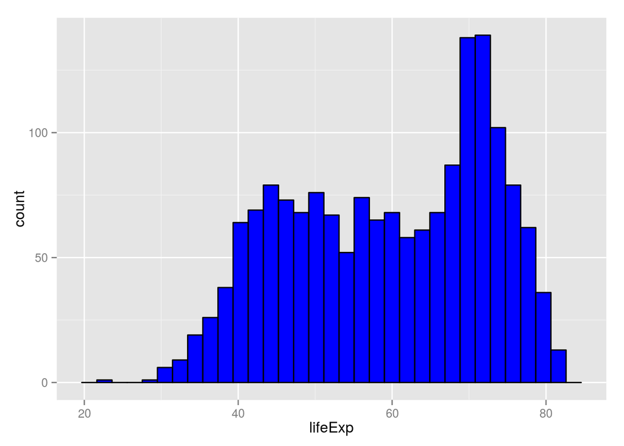

```r
ggplot(mydata, aes(lifeExp)) + geom_histogram(fill="blue", col="black")
```

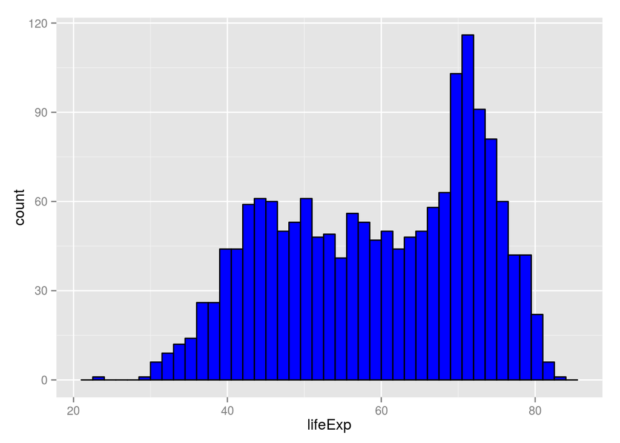

```r
ggplot(mydata, aes(lifeExp)) + geom_histogram(fill="blue", col="black", binwidth=1.5)
```

8. Commit your changes and push them to github.

9. Compile the final Rmd file to html, make sure it looks ok, and then commit this html file as well (should be in your working directory) and push everything to github.